# Exercício 10

Neiton Carvalho da Silva

07/07/2020

# Primeiro Relatório de Neiton no R Markdown

UFRPE - Universidade Federal Rural de Pernambuco  
Disciplina: Computação para Análise de Dados  
Profº Ermeson Andrade

Esta é uma atividade referente ao desenvolvimento de relatórios dinâmicos por meio do R Markdown

## Eu tenho um Sonho

A atividade é fazer uma Nuvem de palavra do discurso **“Eu tenho um sonho”** de *Martin Luther King Jr*. Também plote as palavras mais frequentes  
Fonte texto Eu tenho um sonho link: [clique aqui](http://www.palmares.gov.br/sites/000/2/download/mlk2.pdf)  
Segue o algortimo com explicação de meu processo:

Fiz a instação dos seguintes pacotes:

```r
#Foi instalado os seguintes pacotes

#install.packages("readr")
#install.packages("tm")
#install.packages("wordcloud")
#install.packages("tm.lexicon.GeneralInquirer", repos="http://datacube.wu.ac.at", type="source")
#install.packages("SnowballC")

library(tm.lexicon.GeneralInquirer)
library(tm)
library(wordcloud)
library(readr) # Pra carregar deve usar esta função
library(tm)
library(SnowballC)


getwd()
```

```
## [1] "C:/mestrado_UFRPE_Informatica_Aplicada_Neiton/Computacao_para_Analise_de_Dados/Atividades/Exercício 10/Relatorio_exercicio_10"
```

```r
setwd("C:/mestrado_UFRPE_Informatica_Aplicada_Neiton/Computacao_para_Analise_de_Dados/Atividades/Exercício 10")

sonho <- read.csv("eu_tenho_um_sonho.csv", header = T, stringsAsFactors = FALSE)

#readr --> # Pra carregar deve usar esta função
sonho <- read.csv("eu_tenho_um_sonho.csv")

#Colapsando todos os comentários em um vetor de uma posição
#é como juntar tudo em um único campo
sonho <- paste(sonho$"EU_TENHO_UM_SONHO", collapse = " ")

#Para processar um texto usando o pacote tm, é necessário converter esse dados
#em um formato chamado corpus, que pode ser processado pelo pacote tm.


vs <- VectorSource(sonho)
corpus_sonho <- Corpus(vs)

#Verificando o arquivo corpus gerado

inspect(corpus_sonho)
```

```
## <<SimpleCorpus>>
## Metadata:  corpus specific: 1, document level (indexed): 0
## Content:  documents: 1
##
## [1] Discurso de Martin Luther King (28/08/1963) Eu estou contente em unir-me com vocês no dia que entrará para a história como a maior demonstração pela liberdade na história de nossa nação.\n\nCem anos atrás um grande americano na qual estamos sob sua simbólica sombra assinou a Proclamação   de …
```

```r
#------------------------------------------------------------------------------
#Limpeza
#------------------------------------------------------------------------------

#coloca tudo em minúsculo
corpus_sonho <- tm_map(corpus_sonho, content_transformer(tolower))

#Remove pontuação
corpus_sonho <- tm_map(corpus_sonho, removePunctuation)

#Remove espaços extras em branco
corpus_sonho <- tm_map(corpus_sonho, stripWhitespace)

#Remove números
corpus_sonho <- tm_map(corpus_sonho, removeNumbers)

#Remove palavras ruido(palavras sem significado como exemplo: para, você...)
corpus_sonho <- tm_map(corpus_sonho, removeWords, stopwords('portuguese'))

#Para entender quais são as palavras ruidos é só executar o comando abaixo:
stopwords('portuguese')
```

```
##   [1] "de"           "a"            "o"            "que"          "e"
##   [6] "do"           "da"           "em"           "um"           "para"
##  [11] "com"          "não"          "uma"          "os"           "no"
##  [16] "se"           "na"           "por"          "mais"         "as"
##  [21] "dos"          "como"         "mas"          "ao"           "ele"
##  [26] "das"          "à"            "seu"          "sua"          "ou"
##  [31] "quando"       "muito"        "nos"          "já"           "eu"
##  [36] "também"       "só"           "pelo"         "pela"         "até"
##  [41] "isso"         "ela"          "entre"        "depois"       "sem"
##  [46] "mesmo"        "aos"          "seus"         "quem"         "nas"
##  [51] "me"           "esse"         "eles"         "você"         "essa"
##  [56] "num"          "nem"          "suas"         "meu"          "às"
##  [61] "minha"        "numa"         "pelos"        "elas"         "qual"
##  [66] "nós"          "lhe"          "deles"        "essas"        "esses"
##  [71] "pelas"        "este"         "dele"         "tu"           "te"
```

[output cut: 26 more lines]

```r
#Verificando o arquivo corpus após a limpeza

inspect(corpus_sonho)
```

```
## <<SimpleCorpus>>
## Metadata:  corpus specific: 1, document level (indexed): 0
## Content:  documents: 1
##
## [1] discurso  martin luther king    contente  unirme    dia  entrará   história   maior demonstração  liberdade  história   nação cem anos atrás  grande americano    sob  simbólica sombra assinou  proclamação  emancipação  importante decreto veio   grande farol  esperança  milhões  escravos negro…
```

```r
#Converte para o formato de uma matriz
tdm_sonho <- as.matrix(TermDocumentMatrix(corpus_sonho))

#fornece as frequências ordenadas de cada palavra de acordo com frequência
# Ordem Alfabética
fre_sonho <- sort(rowSums(tdm_sonho))
# Ordem das palavras que mais repetiram
fre_sonho <- sort(rowSums(tdm_sonho), decreasing = TRUE)

#Escolhe um subconjunto dos dados
aux_sonho <- subset(fre_sonho, fre_sonho>2)
```

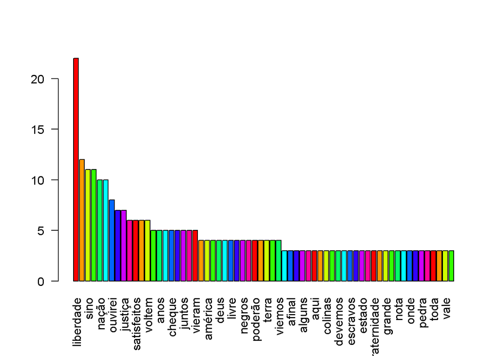

```r
#plota o gráfico de barras dos termos mais frequentes
barplot(aux_sonho, las=2, col = rainbow(10))
```

[figure not shown]

```r
#-------------------------------------------------------------------------------
#GERAR A NUVEM DE PALAVRAS
#-------------------------------------------------------------------------------
#corpus: O vetor de palavras a ser plotado
#min.freq: Palavras com frequência menor que essa não serão mostradas
#mas.words: Máximo de palavrvas a serem plotadas
#random.order: Plota as palavras em ordem randômicas.
               #False significa que são plotadas as palavras mais frequentes.
#rot.per: Quantidade de rotação para aplicar a cada palavra(0-1)
#colors:cores a serem usadas.

wordcloud(corpus_sonho, min.freq = 1, max.words = 100, random.order = FALSE,
          rot.per = 0.35, colors = brewer.pal(8, "Dark2"))
```

## Twitters sobre Black Live Matters.

Etapas para criar a nuvem de palavras no Twitter

```r
#Mineração de dados (Parte 2)

#install.packages("twitteR")
#install.packages("syuzhet")

library(twitteR)
library(tm)
library(wordcloud)
library(syuzhet)
```

```r
setup_twitter_oauth(consumer_key, consumer_secret, access_token, access_secret)
```

```
## [1] "Using direct authentication"
```

```r
#Consultando o Twitter
tweets <- searchTwitter("#BlackLivesMatter", n=300, lang="pt")

#Convertendo os twittes para o formato de DF.
tweets <- twListToDF(tweets)

#Colapsando todos os twittes em um vetor de uma posição
tweets_t <- paste(tweets$text, collapse = " ")

#Criando o source e corpus
tweets_t <- VectorSource(tweets_t)
corpus_tweets <- Corpus(tweets_t)

#Limpeza
corpus_tweets <- tm_map(corpus_tweets, tolower)
corpus_tweets <- tm_map(corpus_tweets, removePunctuation)
corpus_tweets <- tm_map(corpus_tweets, stripWhitespace)
corpus_tweets <- tm_map(corpus_tweets, removeWords, stopwords('portuguese'))
```

```r
inspect(corpus_tweets)
```

```r
#remove URLS
removeURL <- function(x) gsub("http[^[:space:]]*", "", x)
corpus_tweets <- tm_map(corpus_tweets, removeURL)

#remove qualquer coisa que não seja letras em português e espaço.
removeNumPunct <- function(x) gsub("[^[:alpha:][:space:]]*", "", x)
corpus_tweets <- tm_map(corpus_tweets, content_transformer(removeNumPunct))

#cria a matriz
dtm_tweets <- TermDocumentMatrix(corpus_tweets)
dtm_tweets <- as.matrix(dtm_tweets)

#Fornece a frequência de cada palavra
fre_tweets <- sort(rowSums(dtm_tweets), decreasing = TRUE)
```

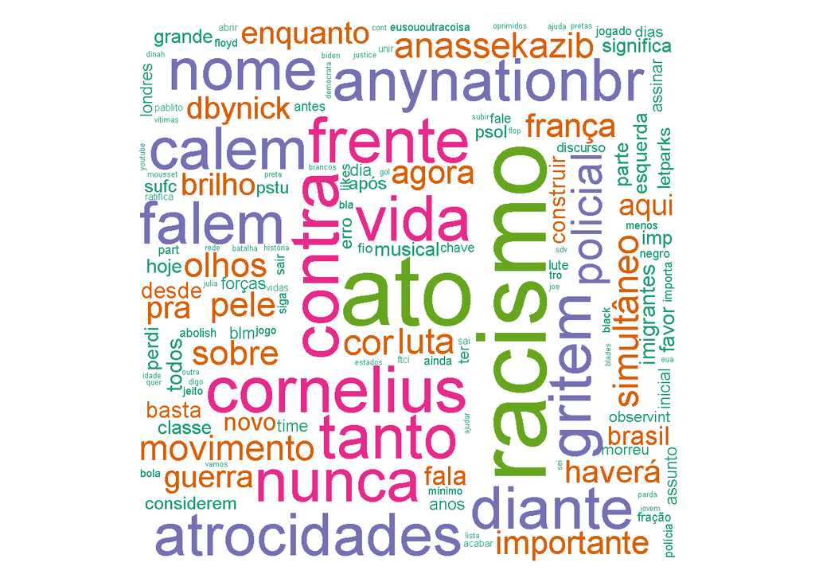

```r
#--------------------------------------------------------
#Gera a nuvem de palavras
#--------------------------------------------------------

#corpus: O vetor de palavras a ser plotado
#min.freq: Palavras com frequência menor que essa não serão mostradas
#mas.words: Máximo de palavrvas a serem plotadas
#random.order: Plota as palavras em ordem randômicas.
#False significa que são plotadas as palavras mais frequentes.
#rot.per: Quantidade de rotação para aplicar a cada palavra(0-1)
#colors:cores a serem usadas.
#scale: Determina o intervalo de tamanho das palavras


wordcloud(corpus_tweets, min.freq = 3,
          max.words = 300, # Se quiser Infinito deve usar - Inf
          random.order = FALSE,
          rot.per = 0.15,
          colors = brewer.pal(8, "Dark2"),
          scale=c(8,.2)
          )
```

Sentimentos Referente a **Black Lives Matter**

```r
#Mineração de dados (Parte 3) - Análise de Sentimentos Twitter

#install.packages("twitteR")
#install.packages("syuzhet")

library(twitteR)
library(tm)
library(syuzhet)
```

```r
setup_twitter_oauth(consumer_key, consumer_secret, access_token, access_secret)
```

```
## [1] "Using direct authentication"
```

```r
#Consultando o Twitter
tweets_sentimentos <- searchTwitter("#BlackLivesMatter", n=500, lang="pt")

#Convertendo os twittes para o formato de Data Frame.
tweets_sentimentos <- twListToDF(tweets_sentimentos)

#Acessando apenas os Textos
tweets_sentimentos <- tweets_sentimentos$text

#Pontuando os tweets
df_Pontuacao <- get_nrc_sentiment(tweets_sentimentos)

#Esse pacote (get_nrc_sentiment) quebra as emoções em 8 tipos diferentes, como exemplo:
#(raiva, antecipação, nojo, medo, alegria, tristeza, surpresa, confiança)
#e os sentimentos em dois tipos (negativo e positivo)
#Sendo que as primeiras são as emoções e as duas ultimas são os sentimentos no caso positivo e negativo
#É utilizado processamento de linguagem natural


View(df_Pontuacao)

#Ver as 06 primeiras linhas
head(df_Pontuacao)
```

```
##   anger anticipation disgust fear joy sadness surprise trust negative positive
## 1     0            0       1    0   0       2        0     0        2        0
## 2     0            0       0    0   0       0        0     0        0        0
## 3     0            0       0    0   0       0        0     0        0        0
## 4     0            0       0    0   0       0        0     0        0        0
## 5     0            0       0    0   0       0        0     0        0        0
## 6     0            0       0    0   0       0        0     0        0        0
```

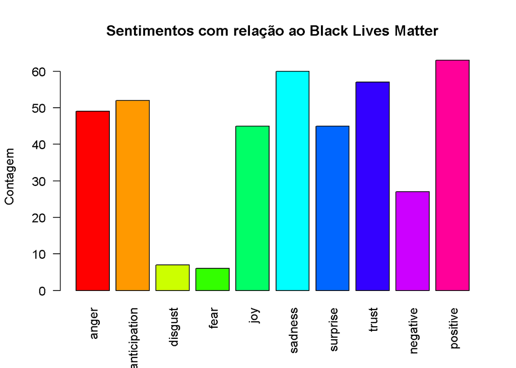

```r
#Plotando os sentimentos
barplot(colSums(df_Pontuacao), las=2, col=rainbow(10),
        ylab="Contagem", main="Sentimentos com relação ao Black Lives Matter")
```

## Figuras

Texto do Título 4 `Texto estilo código` olhando texto código

[figure not shown]

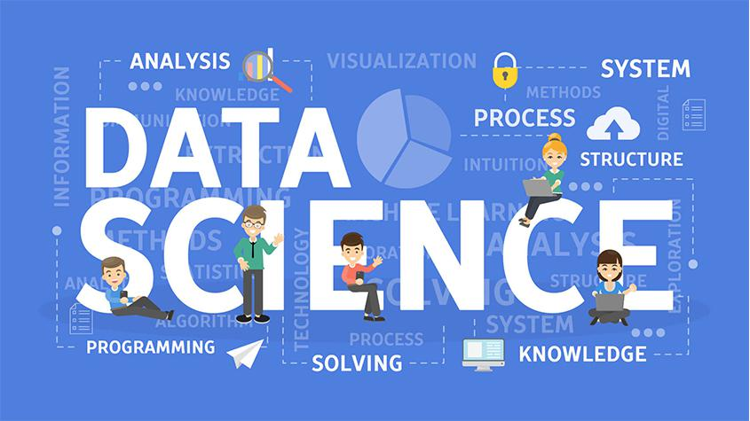

## Equações - Latex

Texto do Título 4 `Texto estilo código` olhando texto código

1º) Equação Complexa:  
$\frac{\int_{x}^{dx}\frac{4}{\sum \sqrt{34\sqrt[5]{2}}}}{\begin{bmatrix} 4 & 5 & \int x\\ \sqrt{2} & \sqrt[6]{\sqrt{9}} & 2\\ \mu & \theta ^2 & \beta \sqrt{4^8} \end{bmatrix}}$

2º) Equação Complexa:  
$\frac{\iint_{\oint_{3}^{d}}^{_{2}^{x}}}{\sum_{5}^{3}}$

3º) Equação Complexa:  
$\begin{Vmatrix} \tfrac{\Phi }{\Xi 5} &\oint 4^{dx} \\ \sigma 6 & \varpi \iint_{\lim_{4dx}}^{} \end{Vmatrix}$

4º) Equação Complexa:  
$\iint_{\int _{\widetilde{a\tfrac{\frac{\partial^2 4}{\partial x^2}}{2}}}^{5}\textrm{3}}^{dx}$

5º) Equação Complexa:  
$\bigcup_{\int 4}^{\frac{\sqrt[7]{5}}{2}}$

## Referências-BibTex

Segue as cinco referências utilizando BibTex:

**Primeira Referência**: Allaire (2012) que é sobre o livro integrated development environment for R.  
Link: [Clique aqui para consultar](http://citeseerx.ist.psu.edu/viewdoc/download?doi=10.1.1.651.1157&rep=rep1&type=pdf#page=14)

**Segunda Referência**: Racine (2012) é sobre a platform-independent IDE for R and Sweave:  
Link: [Clique aqui para consultar](https://www.jstor.org/stable/41337225?seq=1)

**Terceira Referência**: Loraine et al. (2015) é sobre a Analysis and visualization of RNA-Seq expression data using RStudio, Bioconductor, and Integrated Genome Browser:  
Link: [Clique aqui para consultar](https://link.springer.com/protocol/10.1007/978-1-4939-2444-8_24)

**Quarta Referência**: Van der Loo (2012) é sobre Learning RStudio for R statistical computing:  
Link: [Clique aqui para consultar](https://books.google.com.br/books?hl=pt-BR&lr=&id=EE8M9HCJok4C&oi=fnd&pg=PT9&dq=RStudio&ots=lBGA4xCMJM&sig=RWgfXI5IOfB5vTSlItvrwd1AO_Y#v=onepage&q=RStudio&f=false)

**Quinta Referência**: Cirillo (2016) é sobreRStudio for R Statistical Computing Cookbook:  
Link: [Clique aqui para consultar](https://books.google.com.br/books?hl=pt-BR&lr=&id=aN3JDAAAQBAJ&oi=fnd&pg=PP1&dq=RStudio&ots=1cf_wlCAKj&sig=pSR96cCtf32XY__P_oyTNwBzrF4#v=onepage&q=RStudio&f=false)

**REFERÊNCIAS GERADAS:**

Allaire, J. 2012. “RStudio: Integrated Development Environment for R.” *Boston, MA* 770: 394.

Cirillo, Andrea. 2016. *RStudio for R Statistical Computing Cookbook*. Packt Publishing Ltd.

Loraine, Ann E, Ivory Clabaugh Blakley, Sridharan Jagadeesan, Jeff Harper, Gad Miller, and Nurit Firon. 2015. “Analysis and Visualization of Rna-Seq Expression Data Using Rstudio, Bioconductor, and Integrated Genome Browser.” In *Plant Functional Genomics*, 481–501. Springer.

Racine, Jeffrey S. 2012. “RStudio: A Platform-Independent Ide for R and Sweave.” JSTOR.

Van der Loo, Mark PJ. 2012. *Learning Rstudio for R Statistical Computing*. Packt Publishing Ltd.